# High Fat Diet D. melanogaster Project Paper

G5B - Jordi Cugat Bardaji, Eva Sanz Blasco, Biel Vicente Bou & Kexi Wei

2026-05-17

```r
library(Rtsne)
library(ggplot2)
library(plotly)
library(htmltools)
library(dplyr)
library(factoextra)
library(ggfortify)
library(readr)
```

### Dataset introduction

The dataset is obtained from the original publication published in March 12, 2019 from Stobdan et. al: “High fat diet induces sex-specific differential gene expression in Drosophila melanogaster” (doi: 10.1371/journal.pone.0213474)

The paper states that about 2 billion adults globally are estimated to be overweight and ~13% of them are obese. High fat diet (HFD) is one of the major contributing factors to obesity, heart disease, diabetes and cancer. Recent findings on the role of HFD in inducing abnormalities in neurocognition and susceptibility to Alzheimer’s disease are highly intriguing.

As fundamental molecular pathways are often conserved across species, studies involving Drosophila melanogaster as a model organism can provide insight into the molecular mechanisms involving human disease. In order to study some of such mechanisms in the central nervous system as well in the rest of the body, we investigated the effect of HFD on the transcriptome in the heads and bodies of male and female flies kept on either HFD or regular diet (RD).

#### Data loading

```r
exprs_data <- read.table("https://raw.githubusercontent.com/kexi-wei/DV---High-Fat-Dmel/refs/heads/main/SRP171981.tsv",
                        header = TRUE,
                        sep = ",",
                        row.names = 1)
```

```r
meta_data <- read.csv2("https://raw.githubusercontent.com/kexi-wei/DV---High-Fat-Dmel/refs/heads/main/metadata_SRP171981.csv",
                      row.names = 1,
                      header = TRUE)
```

### Data analysis

We transpose the data in order to have the genes as columns and samples as rows.

```r
exprs_data <- t(exprs_data)
exprs_data <- exprs_data[row.names(meta_data),]
```

After checking different parameters of the data, it can be concluded that the experiment has been done with 181 samples, tracking 4 variables (sex, diet, specimen part and replicate), and extracting genetic information from 16913 genes.

```r
# Checking metadata
head(meta_data) # row name: sample_id, variables: sex, diet, specimen_part, replicate
dim(meta_data) # 181 4
str(meta_data) # all chr
sum(is.na(meta_data)) # no missing values

# Check if the samples are in the same order
all.equal(row.names(meta_data),row.names(exprs_data))

# checking exprs_data
head(exprs_data) # variables: genes
dim(exprs_data) # 181 16913
str(exprs_data) # all int
sum(is.na(exprs_data)) # no missing values
```

#### Data frames creation

```r
exprs_data_clean <- exprs_data[, colSums(exprs_data)>0]
exprs_data_norm <- exprs_data_clean/rowSums(exprs_data_clean)
meta_data$total_exp <- rowSums(exprs_data_clean)
```

#### Outliers

We observe that there is a few samples which might be considered outliers due to their low expression (<1.5*IQR) in comparison to the other samples. However, we will not take them out yet in order to compare how does the two diifferent algorithms operate them.

Nevertheless, we will clean them out for the final interpretation to avoid misleading information.

##### Diet

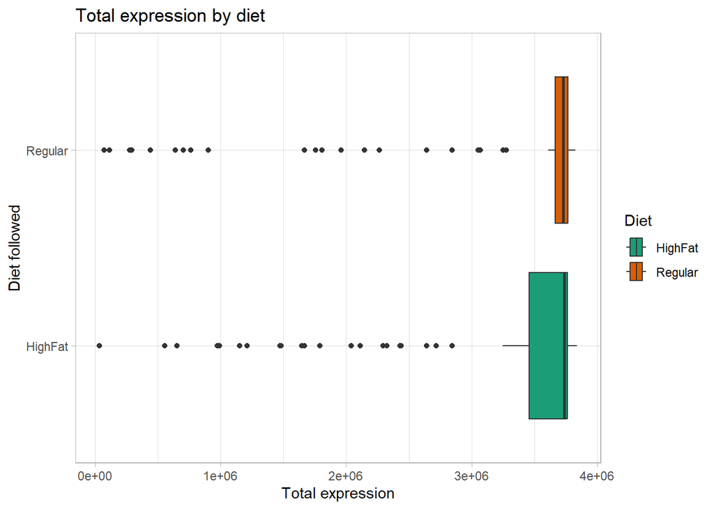

```r
ggplot(meta_data, aes(x = total_exp, y = Diet, fill = Diet)) +
  geom_boxplot() +
  scale_fill_brewer(palette = "Dark2") +
  labs(
    title = "Total expression by diet",
    x = "Total expression",
    y = "Diet followed"
  ) +
  theme_light()
```

##### Specimen part

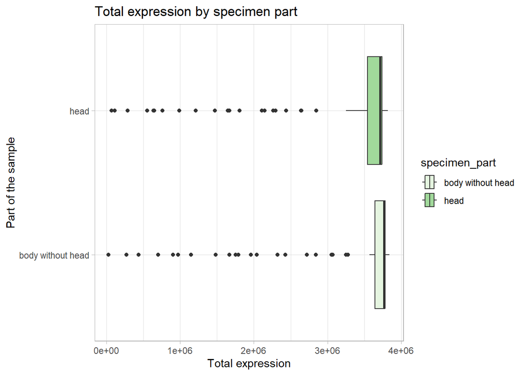

```r
ggplot(meta_data, aes(x = total_exp, y = specimen_part, fill = specimen_part)) +
  geom_boxplot() +
  scale_fill_brewer(palette = "Dark1") +
  labs(
    title = "Total expression by specimen part",
    x = "Total expression",
    y = "Part of the sample"
  ) +
  theme_light()
```

##### Sex

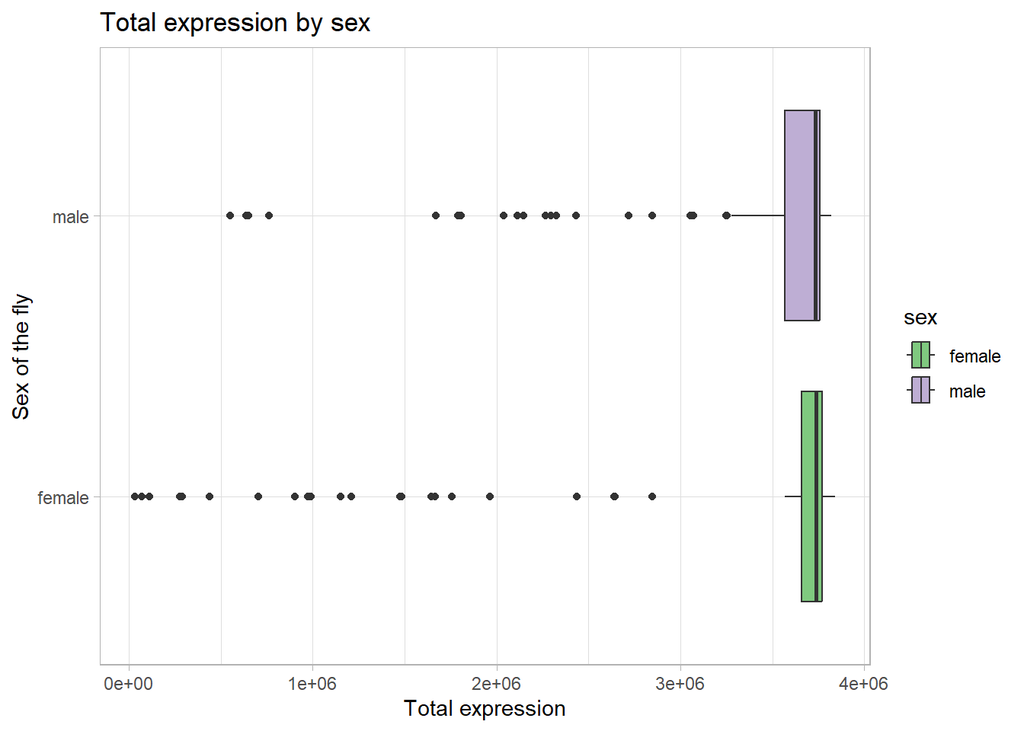

```r
ggplot(meta_data, aes(x = total_exp, y = sex, fill = sex)) +
  geom_boxplot() +
  scale_fill_brewer(palette = "Accent") +
  labs(
    title = "Total expression by sex",
    x = "Total expression",
    y = "Sex of the fly"
  ) +
  theme_light()
```

### PCA Variance explained

From this scree plots, we can deduce that the non-scaled dataset might be dominated by noise. This is because there is a massive variable that explains 72.5% of the variance (probably also causing batch effect), such that it misleads the algorithm to group the samples by that dominant variable, while dropping other biological effects.

However, both scaled and normalized datasets have a more equal variance explained by two principal components. This could mean that there is two main independent factors (not noise) that differentiate this datasets.

```r
plot_pca_scree_function <- function(pca, fill_color = "#698B69") {
  p <- fviz_eig(pca,
                addlabels = TRUE,
                hjust = -0.3,
                barfill = fill_color,
                barcolor = fill_color) +
       theme_light()
  return (p)
  }
```

#### Non-scaled

```r
pca_non_scal <- prcomp(exprs_data, scale. = FALSE, center = TRUE)
```

##### Base plot

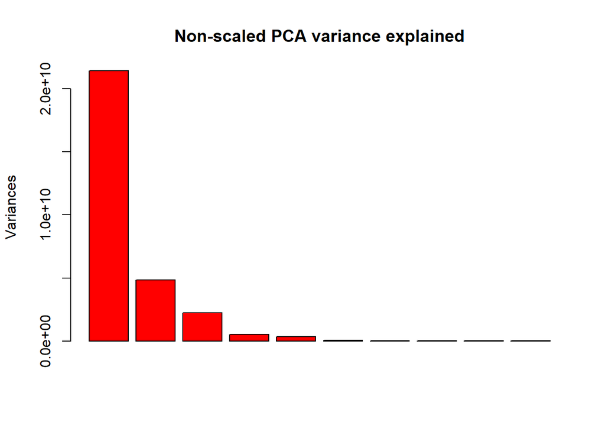

```r
plot(pca_non_scal, col="red", main="Non-scaled PCA variance explained")
```

##### Factoextra

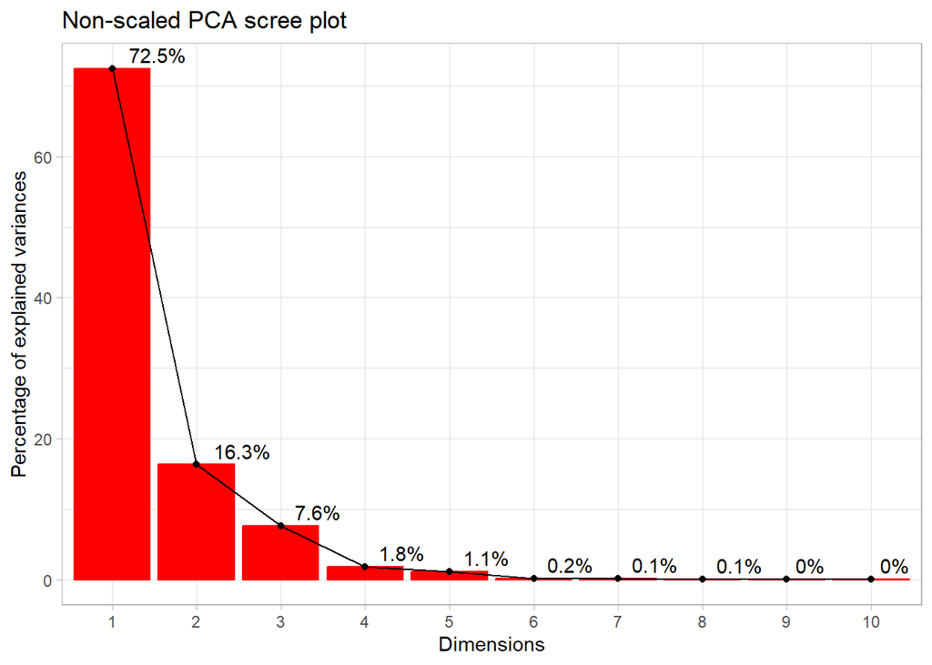

```r
plot_pca_scree_function(pca_non_scal, "red")+
  labs(title="Non-scaled PCA scree plot")
```

#### Scaled

```r
pca_scal <- prcomp(exprs_data_clean, scale. = TRUE, center = TRUE)
```

##### Base plot

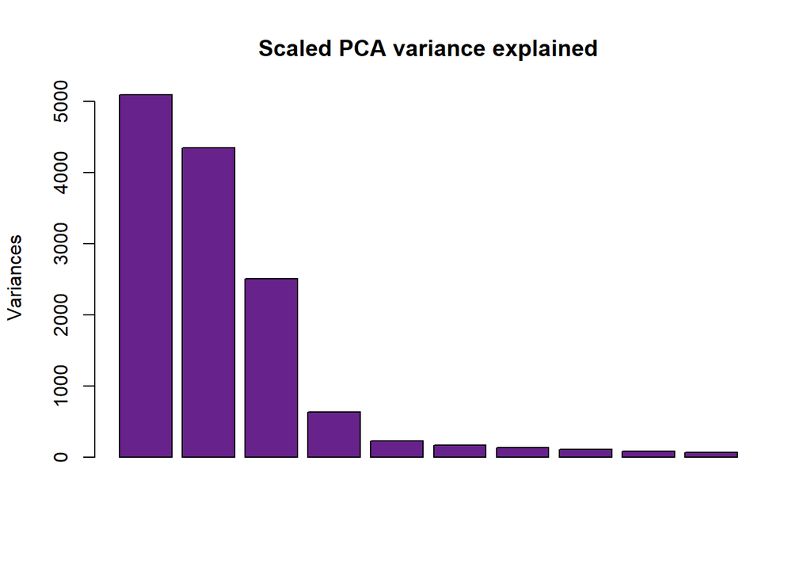

```r
plot(pca_scal, col="#68228B", main="Scaled PCA variance explained")
```

##### Factoextra

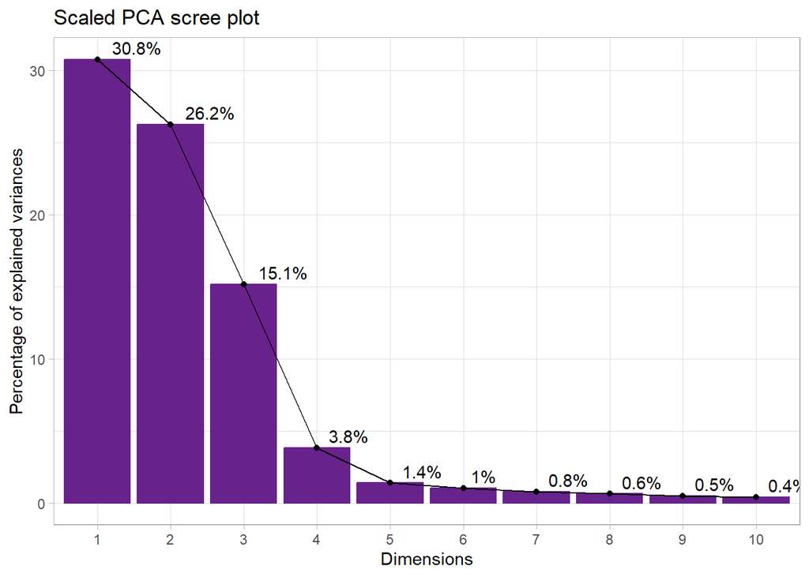

```r
plot_pca_scree_function(pca_scal, "#68228B")+
  labs(title="Scaled PCA scree plot")
```

#### Normalized

```r
pca_result <- prcomp(exprs_data_norm, scale. = TRUE, center = TRUE)
```

##### Base plot

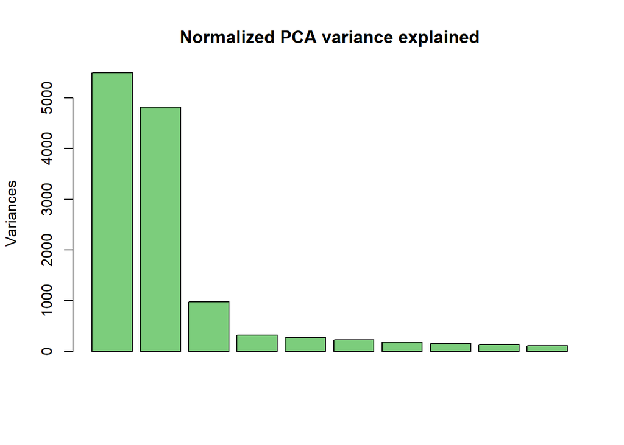

```r
plot(pca_result, col="#7CCD7C", main="Normalized PCA variance explained")
```

##### Factoextra

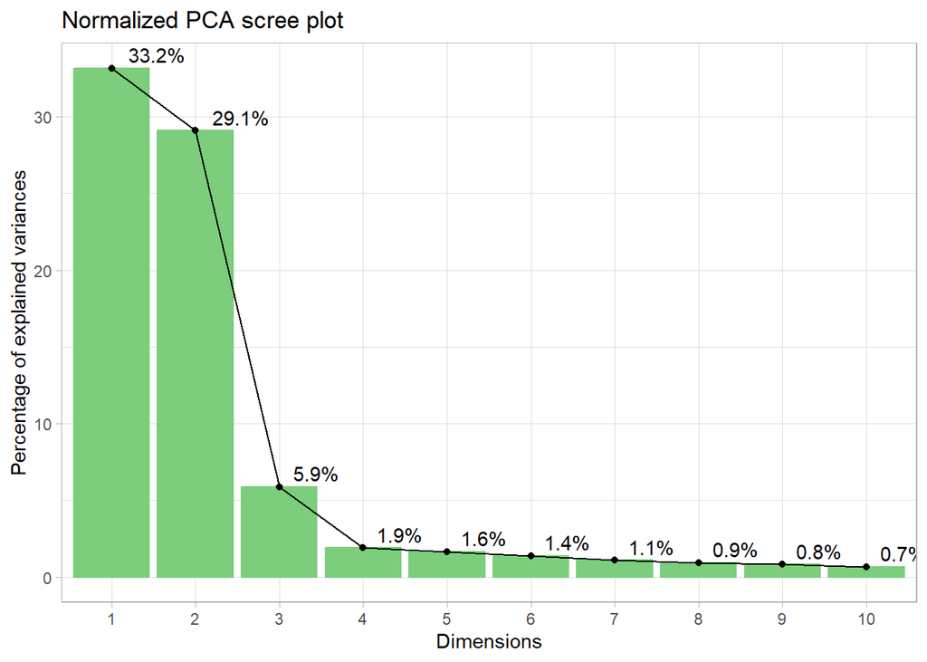

```r
plot_pca_scree_function(pca_result, "#7CCD7C")+
  labs(title="Normalized PCA scree plot")
```

### PCA plot functions

#### Base plot

```r
plot_pca_base <- function(pca) {
  cols <- ifelse(meta_data$Diet == "HighFat", "#1874CD", "#68228B")

  shapes <- ifelse(meta_data$Replicate == "R1", 3,
                 ifelse(meta_data$Replicate == "R2", 15, 17))

  plot(pca$x[, 1:2], xlab = "PC1", ylab = "PC2",
       col = cols,
       pch = shapes,
       cex = 1.2,
       main = "PCA plot by Replicate & Diet")

  legend("topright",
         legend = c("HighFat", "Regular"),
         fill = c("#1874CD", "#68228B"),
         title = "Diet")

  legend("bottomright",
         legend = c("R1", "R2", "R3"),
         pch = c(3, 15, 17),
         col = "black",
         title = "Replicate")
}
```

#### ggplot

```r
plot_pca_ggplot <- function(pca, third_variable) {
  data_plot <- data.frame(
    x = pca$x[,1],
    y = pca$x[,2])

  p <- ggplot(data_plot, aes(x, y,
                             shape = meta_data$Replicate,
                             colour = meta_data$total_exp)) +
    geom_point() +
    scale_color_gradient(name = 'Expression', low = 'green', high = 'red') +
    scale_shape_manual(name = 'Replicate', values = c(3, 15, 17)) +
    facet_wrap(. ~ meta_data[,third_variable]) +
    theme_light()+
    xlab("PCA1")+
    ylab("PCA2")

  return(plotly::ggplotly(p))
}
```

#### ggfortify

```r
plot_pca_ggfortify <- function(pca, third_variable) {
  p <- ggplot2::autoplot(pca,
                         data = meta_data,
                         shape = "Replicate",
                         colour = "total_exp") +
    scale_color_gradient(name = 'Expression', low = 'green', high = 'red') +
    scale_shape_manual(name = 'Replicate', values = c(3, 15, 17)) +
    facet_wrap(. ~ meta_data[,third_variable]) +
    theme_light() +
    xlab("PCA1") +
    ylab("PCA2")

  return(plotly::ggplotly(p))
  }
```

### PCA plots

#### Non-scaled

##### Base plot

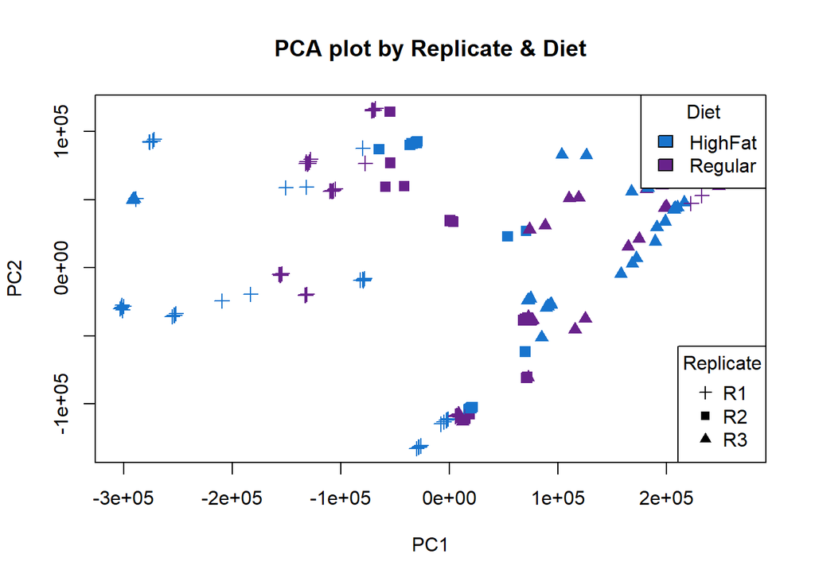

```r
plot_pca_base(pca_non_scal)
```

##### ggplot

###### Diet

```r
plot_pca_ggplot(pca_non_scal, "Diet")
```

[interactive chart not shown]

###### Specimen part

```r
plot_pca_ggplot(pca_non_scal, "specimen_part")
```

[interactive chart not shown]

###### Sex

```r
plot_pca_ggplot(pca_non_scal, "sex")
```

[interactive chart not shown]

##### ggfortify

###### Diet

```r
plot_pca_ggfortify(pca_non_scal, "Diet")
```

[interactive chart not shown]

###### Specimen part

```r
plot_pca_ggfortify(pca_non_scal, "specimen_part")
```

[interactive chart not shown]

###### Sex

```r
plot_pca_ggfortify(pca_non_scal, "sex")
```

[interactive chart not shown]

#### Scaled

##### Base plot

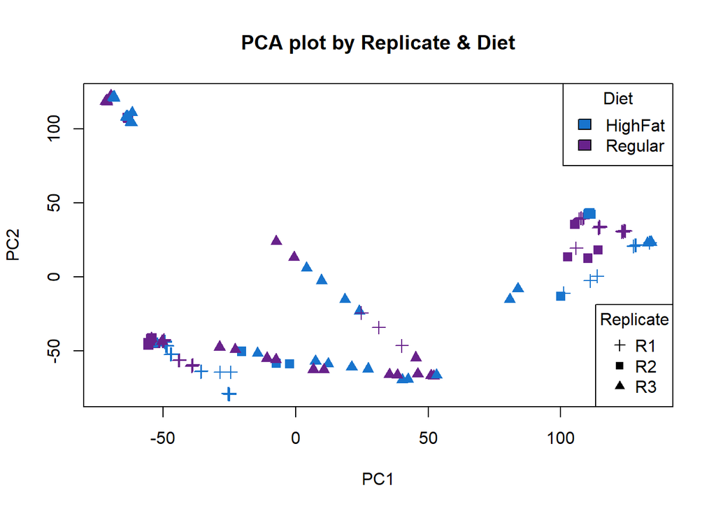

```r
plot_pca_base(pca_scal)
```

##### ggplot

###### Diet

```r
plot_pca_ggplot(pca_scal, "Diet")
```

[interactive chart not shown]

###### Specimen part

```r
plot_pca_ggplot(pca_scal, "specimen_part")
```

[interactive chart not shown]

###### Sex

```r
plot_pca_ggplot(pca_scal, "sex")
```

[interactive chart not shown]

##### ggfortify

###### Diet

```r
plot_pca_ggfortify(pca_scal, "Diet")
```

[interactive chart not shown]

###### Specimen part

```r
plot_pca_ggfortify(pca_scal, "specimen_part")
```

[interactive chart not shown]

###### Sex

```r
plot_pca_ggfortify(pca_scal, "sex")
```

[interactive chart not shown]

#### Normalized

##### Base plot

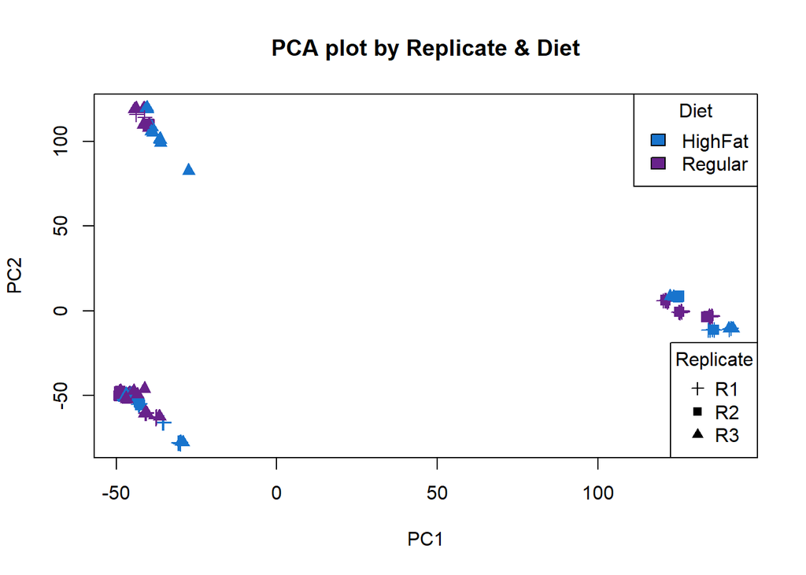

```r
plot_pca_base(pca_result)
```

##### ggplot

###### Diet

```r
plot_pca_ggplot(pca_result, "Diet")
```

[interactive chart not shown]

###### Specimen part

```r
plot_pca_ggplot(pca_result, "specimen_part")
```

[interactive chart not shown]

###### Sex

```r
plot_pca_ggplot(pca_result, "sex")
```

[interactive chart not shown]

##### ggfortify

###### Diet

```r
plot_pca_ggfortify(pca_result, "Diet")
```

[interactive chart not shown]

###### Specimen part

```r
plot_pca_ggfortify(pca_result, "specimen_part")
```

[interactive chart not shown]

###### Sex

```r
plot_pca_ggfortify(pca_result, "sex")
```

[interactive chart not shown]

### Create PCA Data Frames

```r
df_non_scal <- data.frame(
  PC1 = pca_non_scal$x[,1],
  PC2 = pca_non_scal$x[,2],
  diet = meta_data$Diet,
  rep = meta_data$Replicate,
  sex = meta_data$sex,
  exp = meta_data$total_exp,
  part = meta_data$specimen_part,
  Method = "Non-scaled"
)

df_scal <- data.frame(
  PC1 = pca_scal$x[,1],
  PC2 = pca_scal$x[,2],
  diet = meta_data$Diet,
  rep = meta_data$Replicate,
  sex = meta_data$sex,
  exp = meta_data$total_exp,
  part = meta_data$specimen_part,
  Method = "Scaled"
)

df_norm <- data.frame(
  PC1 = pca_result$x[,1],
  PC2 = pca_result$x[,2],
  diet = meta_data$Diet,
  rep = meta_data$Replicate,
  sex = meta_data$sex,
  exp = meta_data$total_exp,
  part = meta_data$specimen_part,
  Method = "Normalized"
)

# Combine all PCA results
df_all <- bind_rows(df_non_scal, df_scal, df_norm)

# Set facet order
df_all$Method <- factor(
  df_all$Method,
  levels = c("Non-scaled", "Scaled", "Normalized")
)
```

### PCA Comparison Plot

#### Diet

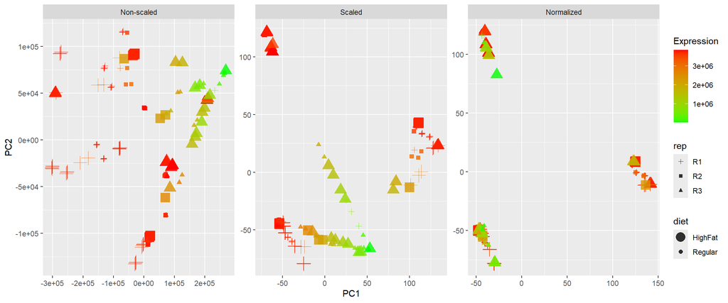

```r
ggplot(df_all,
       aes(x = PC1,
           y = PC2,
           colour = exp,
           shape = rep,
           size = diet)) +

  geom_point(alpha = 0.8) +

  facet_wrap(~Method, scales = "free") +

  scale_shape_manual(values = c(
    "R1" = 3,
    "R2" = 15,
    "R3" = 17
  )) +
  scale_color_gradient(name = 'Expression', low = 'green', high = 'red') +

  scale_size_manual(values = c(
    "Regular" = 2,
    "HighFat" = 5))
```

#### Specimen part

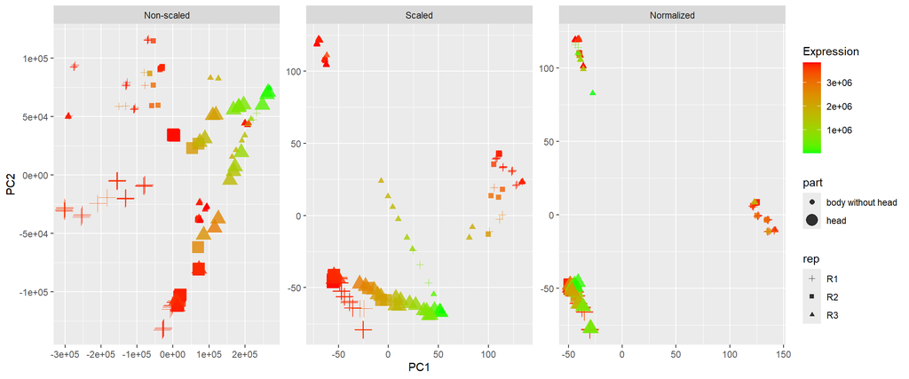

```r
ggplot(df_all,
       aes(x = PC1,
           y = PC2,
           colour = exp,
           shape = rep,
           size = part)) +

  geom_point(alpha = 0.8) +

  facet_wrap(~Method, scales = "free") +

  scale_shape_manual(values = c(
    "R1" = 3,
    "R2" = 15,
    "R3" = 17
  )) +
  scale_color_gradient(name = 'Expression', low = 'green', high = 'red') +

  scale_size_manual(values = c(
    "body without head" = 2,
    "head" = 5))
```

#### Sex

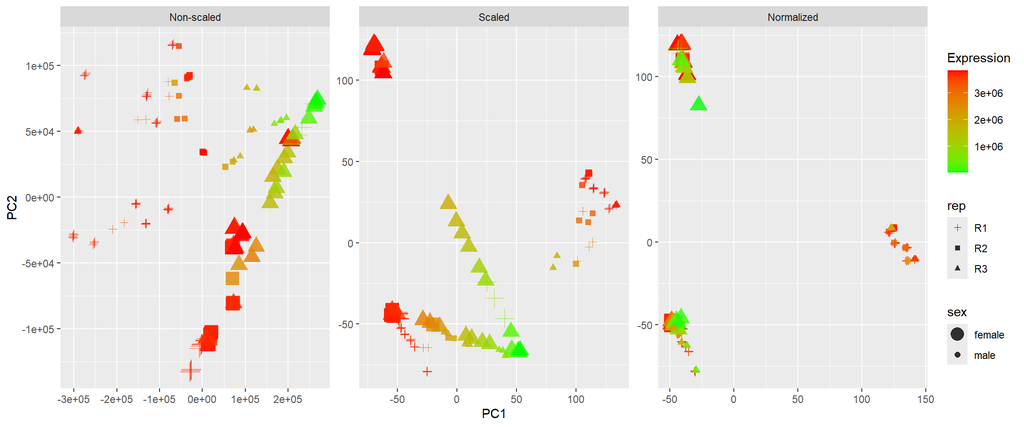

```r
ggplot(df_all,
       aes(x = PC1,
           y = PC2,
           colour = exp,
           shape = rep,
           size = sex)) +

  geom_point(alpha = 0.8) +

  facet_wrap(~Method, scales = "free") +

  scale_shape_manual(values = c(
    "R1" = 3,
    "R2" = 15,
    "R3" = 17
  )) +
  scale_color_gradient(name = 'Expression', low = 'green', high = 'red') +

  scale_size_manual(values = c(
    "male" = 2,
    "female" = 5))
```

### tSNE

```r
set.seed(42)
tsne_raw <- Rtsne(exprs_data)
set.seed(42)
tsne_norm <- Rtsne(exprs_data_norm)
```

```r
plot_tsne_function <- function(tsne_res, third_variable) {
  tsne_plot <- data.frame(x = tsne_res$Y[,1],
                          y = tsne_res$Y[,2])

  p <- ggplot(tsne_plot, aes(x, y,
                             shape = meta_data$Replicate,
                             colour = meta_data$total_exp)) +
    geom_point() +
    scale_color_gradient(name = 'Expression', low = 'green', high = 'red') +
    scale_shape_manual(name = 'Replicate', values = c(3, 15, 17)) +
    facet_wrap(. ~ meta_data[,third_variable]) +
    theme_light()+
    xlab("tSNE1")+
    ylab("tSNE2")
  div(style = 'width: 600px; margin-left: auto; margin-right: auto;', ggplotly(p))
}
```

#### Alternative Code

```r
plot_tsne_ggfortify <- function(tsne_res, third_variable) {
  df_tsne <- data.frame(x = tsne_res$Y[,1], y = tsne_res$Y[,2])
  plot_data <- cbind(df_tsne, meta_data)
  p <- ggplot2::ggplot(plot_data, ggplot2::aes(x,
                                               y,
                                               shape = Replicate,
                                               colour = total_exp)) +
    geom_point() +
    scale_color_gradient(name = 'Expression', low = 'green', high = 'red') +
    scale_shape_manual(name = 'Replicate', values = c(3, 15, 17)) +
    facet_wrap(stats::as.formula(paste("~", third_variable))) +
    theme_light() +
    xlab("tSNE1") +
    ylab("tSNE2")

  return(plotly::ggplotly(p))
  }
```

### tSNE Visualization

#### Diet

##### Raw data

```r
plot_tsne_function(tsne_raw, 'Diet')
```

[interactive chart not shown]

##### Normalized data

```r
plot_tsne_function(tsne_norm, 'Diet')
```

[interactive chart not shown]

#### Specimen Part

##### Raw data

```r
plot_tsne_function(tsne_raw, 'specimen_part')
```

[interactive chart not shown]

##### Normalized data

```r
plot_tsne_function(tsne_norm, 'specimen_part')
```

[interactive chart not shown]

#### Sex

##### Raw data

```r
plot_tsne_function(tsne_raw, 'sex')
```

[interactive chart not shown]

##### Normalized data

```r
plot_tsne_function(tsne_norm, 'sex')
```

[interactive chart not shown]

### Create tSNE Data Frames

```r
df_raw <- data.frame(
  tSNE1 = tsne_raw$Y[,1],
  tSNE2 = tsne_raw$Y[,2],
  diet = meta_data$Diet,
  rep = meta_data$Replicate,
  sex = meta_data$sex,
  exp = meta_data$total_exp,
  part = meta_data$specimen_part,
  Method_tsne = "Raw"
)

df_norma <- data.frame(
  tSNE1 = tsne_norm$Y[,1],
  tSNE2 = tsne_norm$Y[,2],
  diet = meta_data$Diet,
  rep = meta_data$Replicate,
  sex = meta_data$sex,
  exp = meta_data$total_exp,
  part = meta_data$specimen_part,
  Method_tsne = "Normalized"
)

df_all_tsne <- bind_rows(df_raw, df_norma)

df_all_tsne$Method_tsne <- factor(
  df_all_tsne$Method_tsne,
  levels = c("Raw", "Normalized")
)
```

### tSNE Comparison Plot

Thus, after plotting the normalized plot, we can observe that the batch effect has disappeared as most of the clusters are formed from a mix of samples from different replicate. The axis itself does not have any meaning in tSNE, but the distance of the points between them is key. Hence, from this plot we can infer that the sex might be the most variable factor as its clusters clearly segregate male and female samples. Whereas the clusters from diet and specimen part seem to be more heterogeneous.

#### Diet

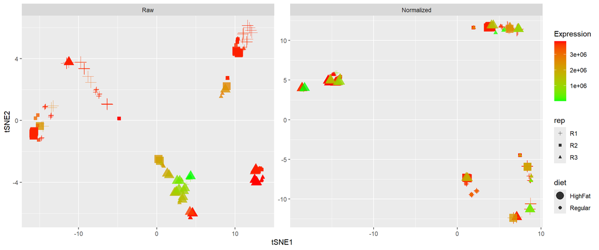

```r
ggplot(df_all_tsne,
       aes(x = tSNE1,
           y = tSNE2,
           colour = exp,
           shape = rep,
           size = diet)) +

  geom_point(alpha = 0.8) +

  facet_wrap(~Method_tsne, scales = "free") +

  scale_shape_manual(values = c(
    "R1" = 3,
    "R2" = 15,
    "R3" = 17
  )) +
  scale_color_gradient(name = 'Expression', low = 'green', high = 'red') +

  scale_size_manual(values = c(
    "Regular" = 2,
    "HighFat" = 5))
```

#### Specimen part

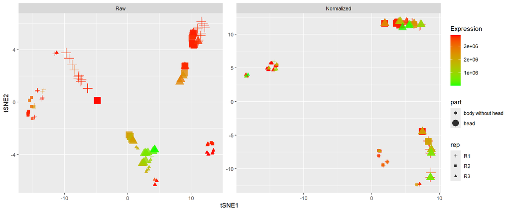

```r
ggplot(df_all_tsne,
       aes(x = tSNE1,
           y = tSNE2,
           colour = exp,
           shape = rep,
           size = part)) +

  geom_point(alpha = 0.8) +

  facet_wrap(~Method_tsne, scales = "free") +

  scale_shape_manual(values = c(
    "R1" = 3,
    "R2" = 15,
    "R3" = 17
  )) +
  scale_color_gradient(name = 'Expression', low = 'green', high = 'red') +

  scale_size_manual(values = c(
    "body without head" = 2,
    "head" = 5))
```

#### Sex

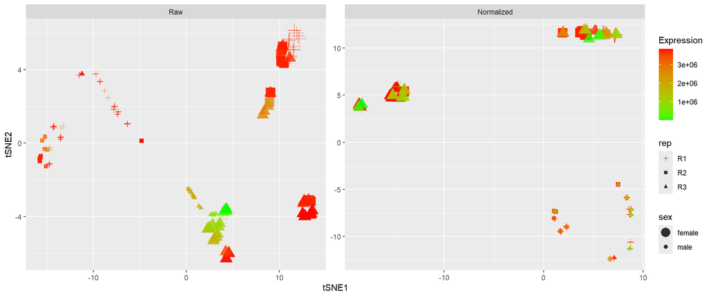

```r
ggplot(df_all_tsne,
       aes(x = tSNE1,
           y = tSNE2,
           colour = exp,
           shape = rep,
           size = sex)) +

  geom_point(alpha = 0.8) +

  facet_wrap(~Method_tsne, scales = "free") +

  scale_shape_manual(values = c(
    "R1" = 3,
    "R2" = 15,
    "R3" = 17
  )) +
  scale_color_gradient(name = 'Expression', low = 'green', high = 'red') +

  scale_size_manual(values = c(
    "male" = 2,
    "female" = 5))
```

### tSNE parameters

#### Reproductibility

After running the code 3 times for each variable we can observe differences between each plot, but the data seems to be similar in the amount and shape of clusters, they are just in different positions or orientations across the plots.

This is corrected by specifying the seed before doing the Rtsne as we had already done before using the seed 42.

```r
#Reproductibility
#(code for normalized data without specified seed)
tsne_norm1 <- Rtsne(exprs_data_norm)
tsne_norm2 <- Rtsne(exprs_data_norm)
tsne_norm3 <- Rtsne(exprs_data_norm)
```

```r
df_tsne1 <- data.frame(
  tSNE1  = tsne_norm1$Y[,1],
  tSNE2  = tsne_norm2$Y[,2],
  diet   = meta_data$Diet,
  rep    = meta_data$Replicate,
  sex    = meta_data$sex,
  exp    = meta_data$total_exp,
  part   = meta_data$specimen_part,
  Method_rep = "Try 1"
)

df_tsne2 <- data.frame(
  tSNE1  = tsne_norm2$Y[,1],
  tSNE2  = tsne_norm2$Y[,2],
  diet   = meta_data$Diet,
  rep    = meta_data$Replicate,
  sex    = meta_data$sex,
  exp    = meta_data$total_exp,
  part   = meta_data$specimen_part,
  Method_rep = "Try 2"
)

df_tsne3 <- data.frame(
  tSNE1  = tsne_norm3$Y[,1],
  tSNE2  = tsne_norm3$Y[,2],
  diet   = meta_data$Diet,
  rep    = meta_data$Replicate,
  sex    = meta_data$sex,
  exp    = meta_data$total_exp,
  part   = meta_data$specimen_part,
  Method_rep = "Try 3"
)

df_tsne_rep <- bind_rows(df_tsne1, df_tsne2, df_tsne3)

df_tsne_rep$Method_rep <- factor(
  df_tsne_rep$Method_rep,
  levels = c("Try 1", "Try 2", "Try 3")
)
```

##### Diet

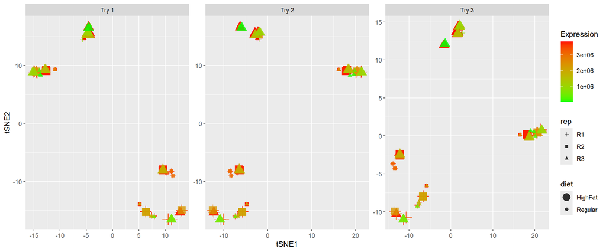

```r
ggplot(df_tsne_rep,
       aes(x = tSNE1,
           y = tSNE2,
           colour = exp,
           shape = rep,
           size = diet)) +

  geom_point(alpha = 0.8) +

  facet_wrap(~Method_rep, scales = "free") +

  scale_shape_manual(values = c(
    "R1" = 3,
    "R2" = 15,
    "R3" = 17
  )) +
  scale_color_gradient(name = 'Expression', low = 'green', high = 'red') +

  scale_size_manual(values = c(
    "Regular" = 2,
    "HighFat" = 5))
```

##### Specimen part

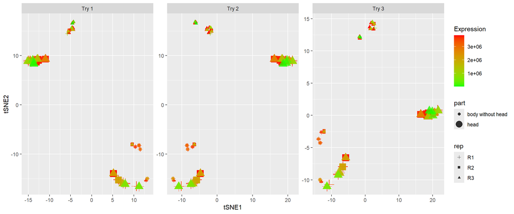

```r
ggplot(df_tsne_rep,
       aes(x = tSNE1,
           y = tSNE2,
           colour = exp,
           shape = rep,
           size = part)) +

  geom_point(alpha = 0.8) +

  facet_wrap(~Method_rep, scales = "free") +

  scale_shape_manual(values = c(
    "R1" = 3,
    "R2" = 15,
    "R3" = 17
  )) +
  scale_color_gradient(name = 'Expression', low = 'green', high = 'red') +

  scale_size_manual(values = c(
    "body without head" = 2,
    "head" = 5))
```

##### Sex

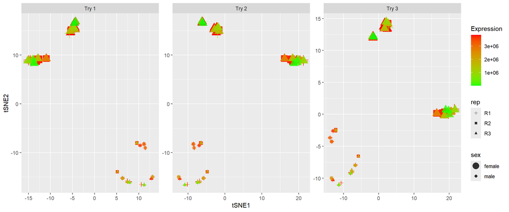

```r
ggplot(df_tsne_rep,
       aes(x = tSNE1,
           y = tSNE2,
           colour = exp,
           shape = rep,
           size = sex)) +

  geom_point(alpha = 0.8) +

  facet_wrap(~Method_rep, scales = "free") +

  scale_shape_manual(values = c(
    "R1" = 3,
    "R2" = 15,
    "R3" = 17
  )) +
  scale_color_gradient(name = 'Expression', low = 'green', high = 'red') +

  scale_size_manual(values = c(
    "male" = 2,
    "female" = 5))
```

#### Perplexity

As perplexity controls how many neighbors each point considers, the lower values give more noisy and spread out plots while higher values give plots with more clustered points and more understandable.

The base value of perplexity is 30 and it is enough to get a plot with well defined clusters that works in order to study it.

```r
plot_function <- function(exprs_data_norm, meta_data, third_variable, perp, seed=42) {
  set.seed(42)
  tsne_norm <- Rtsne(exprs_data_norm, perplexity = perp)

  tsne_plot <- data.frame(
    x = tsne_norm$Y[, 1],
    y = tsne_norm$Y[, 2],
    Replicate = meta_data$Replicate,
    total_exp = meta_data$total_exp,
    facet_var = meta_data[[third_variable]]
  )

  p <- ggplot(tsne_plot, aes(x, y, shape = Replicate, colour = total_exp)) +
    geom_point() +
    scale_color_gradient(name = "Expression", low = "green", high = "red") +
    scale_shape_manual(name = "Replicate", values = c(3, 15, 17)) +
    facet_wrap(vars(facet_var)) +
    theme_light() +
    labs(title = paste("t-SNE, perplexity =", perp, "| seed =", seed))

  div(style = "width: 600px; margin-left: auto; margin-right: auto;", ggplotly(p))
}
```

##### Diet

###### Perplexity = 1

```r
plot_function(exprs_data_norm, meta_data, 'Diet', 1)
```

[interactive chart not shown]

###### Perplexity = 10

```r
plot_function(exprs_data_norm, meta_data, 'Diet', 10)
```

[interactive chart not shown]

###### Perplexity = 30

```r
plot_function(exprs_data_norm, meta_data, 'Diet', 30)
```

[interactive chart not shown]

###### Perplexity = 50

```r
plot_function(exprs_data_norm, meta_data, 'Diet', 50)
```

[interactive chart not shown]

##### Specimen part

###### Perplexity = 1

```r
plot_function(exprs_data_norm, meta_data, 'specimen_part', 1)
```

[interactive chart not shown]

###### Perplexity = 10

```r
plot_function(exprs_data_norm, meta_data, 'specimen_part', 10)
```

[interactive chart not shown]

###### Perplexity = 30

```r
plot_function(exprs_data_norm, meta_data, 'specimen_part', 30)
```

[interactive chart not shown]

###### Perplexity = 50

```r
plot_function(exprs_data_norm, meta_data, 'specimen_part', 50)
```

[interactive chart not shown]

##### Sex

###### Perplexity = 1

```r
plot_function(exprs_data_norm, meta_data, 'sex', 1)
```

[interactive chart not shown]

###### Perplexity = 10

```r
plot_function(exprs_data_norm, meta_data, 'sex', 10)
```

[interactive chart not shown]

###### Perplexity = 30

```r
plot_function(exprs_data_norm, meta_data, 'sex', 30)
```

[interactive chart not shown]

###### Perplexity = 50

```r
plot_function(exprs_data_norm, meta_data, 'sex', 50)
```

[interactive chart not shown]

#### Iterations

The number of iterations controls how far tSNE optimizes, similarly to perplexity, the less iterations give more spread out and noisy plots, while larger values cluster points together and make the plots understandable to study them.

The base iteration value is 1000 and we can observe that it is enough as the plots with 2000 iterations give almost the same result as the ones with 1000, but the ones with 100 are not enough because their points are not clustered together as much.

```r
plot_function2 <- function(exprs_data_norm, meta_data, third_variable, iterations, seed = 42) {
  set.seed(seed)
  tsne_norm <- Rtsne(exprs_data_norm, max_iter = iterations)

  tsne_plot <- data.frame(
    x = tsne_norm$Y[, 1],
    y = tsne_norm$Y[, 2],
    Replicate = meta_data$Replicate,
    total_exp = meta_data$total_exp,
    facet_var = meta_data[[third_variable]]
  )

  p <- ggplot(tsne_plot, aes(x, y, shape = Replicate, colour = total_exp)) +
    geom_point() +
    scale_color_gradient(name = "Expression", low = "green", high = "red") +
    scale_shape_manual(name = "Replicate", values = c(3, 15, 17)) +
    facet_wrap(vars(facet_var)) +
    theme_light() +
    labs(title = paste("t-SNE, iterations =", iterations, "| seed =", seed))

  div(style = "width: 600px; margin-left: auto; margin-right: auto;", ggplotly(p))
}
```

##### Diet

###### Iterations = 1

```r
plot_function2(exprs_data_norm, meta_data, "Diet", 1)
```

[interactive chart not shown]

###### Iterations = 100

```r
plot_function2(exprs_data_norm, meta_data, "Diet", 100)
```

[interactive chart not shown]

###### Iterations = 1000

```r
plot_function2(exprs_data_norm, meta_data, "Diet", 1000)
```

[interactive chart not shown]

###### Iterations = 2000

```r
plot_function2(exprs_data_norm, meta_data, "Diet", 2000)
```

[interactive chart not shown]

##### Specimen part

###### Iterations = 1

```r
plot_function2(exprs_data_norm, meta_data, "specimen_part", 1)
```

[interactive chart not shown]

###### Iterations = 100

```r
plot_function2(exprs_data_norm, meta_data, "specimen_part", 100)
```

[interactive chart not shown]

###### Iterations = 1000

```r
plot_function2(exprs_data_norm, meta_data, "specimen_part", 1000)
```

[interactive chart not shown]

###### Iterations = 2000

```r
plot_function2(exprs_data_norm, meta_data, "specimen_part", 2000)
```

[interactive chart not shown]

##### Sex

###### Iterations = 1

```r
plot_function2(exprs_data_norm, meta_data, "sex", 1)
```

[interactive chart not shown]

###### Iterations = 100

```r
plot_function2(exprs_data_norm, meta_data, "sex", 100)
```

[interactive chart not shown]

###### Iterations = 1000

```r
plot_function2(exprs_data_norm, meta_data, "sex", 1000)
```

[interactive chart not shown]

###### Iterations = 2000

```r
plot_function2(exprs_data_norm, meta_data, "sex", 2000)
```

[interactive chart not shown]

### Outlier handling

Now, for the interpretation, we will add a new variable in the metadata where it stores whether a point’s expression misses or exceeds outside the 1.5*IQR.

```r
Q1 <- quantile(meta_data$total_exp, 0.25)
Q3 <- quantile(meta_data$total_exp, 0.75)
IQR_val <- IQR(meta_data$total_exp)

lower_bound <- Q1 - 1.5 * IQR_val
upper_bound <- Q3 + 1.5 * IQR_val

meta_data$outlier <- ifelse(
  meta_data$total_exp < lower_bound | meta_data$total_exp > upper_bound,
  "Outlier", "Normal")
```

We also need to check if the outliers come from the same replicate, meaning that there is a batch effect due to an error in the sampling part.

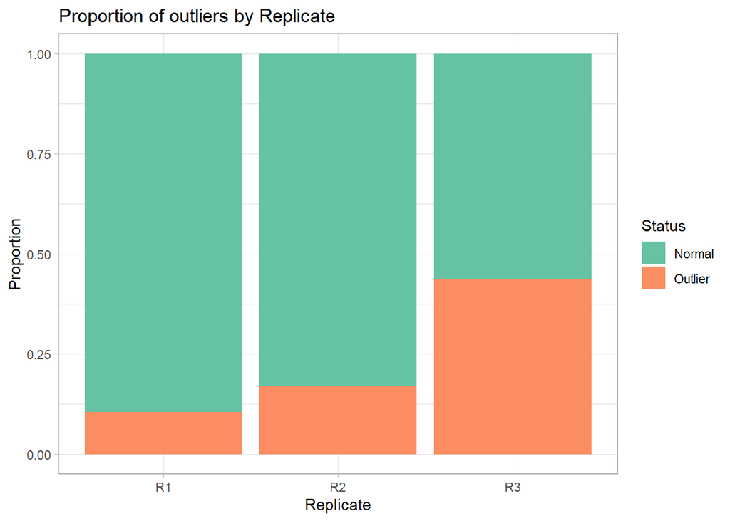

```r
data_plot_pca <- cbind(pca_result$x, meta_data)
ggplot(data_plot_pca, aes(x = Replicate, fill = outlier)) +
  geom_bar(position = "fill") +
  scale_fill_brewer(palette = "Set2", name = "Status") +
  labs(
    title = "Proportion of outliers by Replicate",
    x = "Replicate",
    y = "Proportion"
  ) +
  theme_light()
```

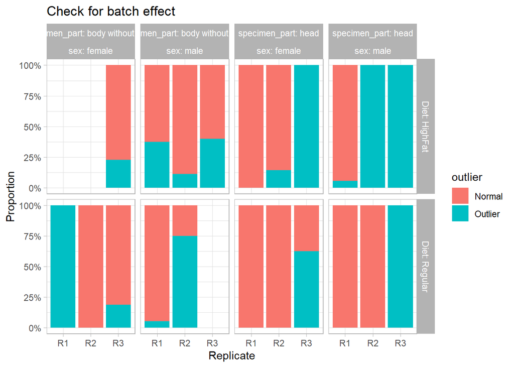

```r
ggplot(data_plot_pca, aes(x = Replicate, fill = outlier)) +
  geom_bar(position = "fill") +
  scale_y_continuous(labels = scales::percent) +
  facet_grid(Diet ~ specimen_part+sex, labeller = label_both) +
  theme_light() +
  labs(title = "Check for batch effect", y = "Proportion")
```

As a conclusion, it can be clearly seen an error on the sampling of the heads of replicate 3 (independent on sex or diet). So, the presence of whole replicate groups having 100% outliers within identical tissue, sex, and diet could mean the existence of a technical batch effect.

#### PCA

```r
plot_pca_ggplot(pca_result, "outlier")
```

[interactive chart not shown]

##### Alternative code

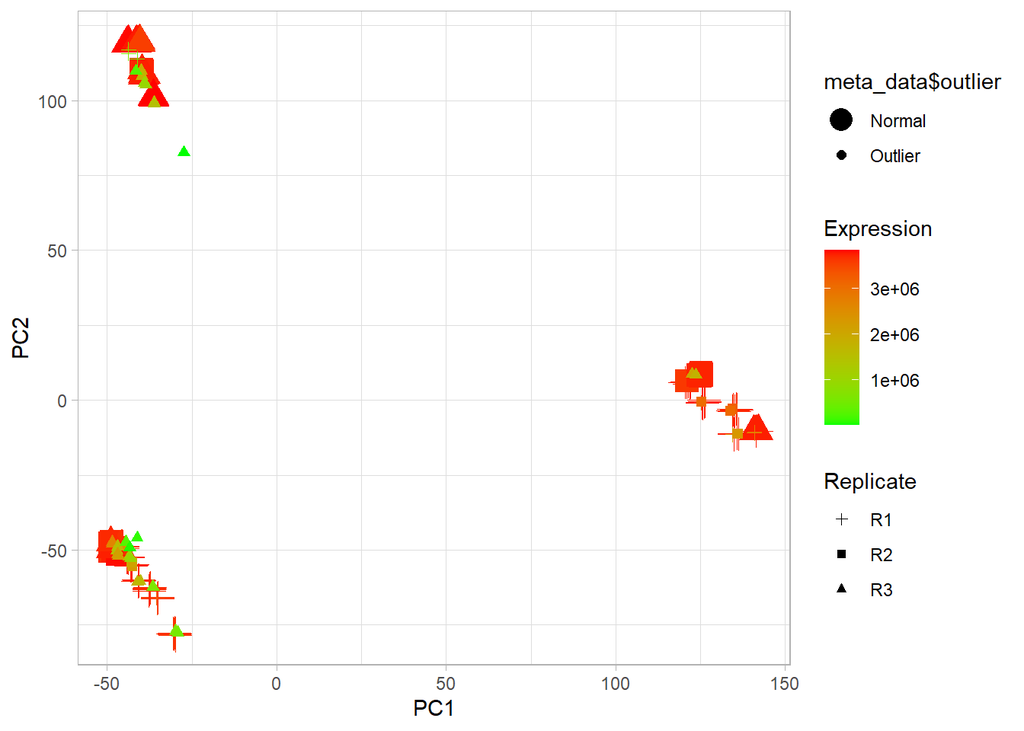

```r
ggplot(pca_result, aes(x=PC1, y=PC2, shape=meta_data$Replicate, colour = meta_data$total_exp, size=meta_data$outlier))+
  geom_point()+
  scale_color_gradient(name = 'Expression', low = 'green', high = 'red') +
  scale_shape_manual(name = 'Replicate', values = c(3, 15, 17))+
  scale_size_manual(values = c("Normal" = 5, "Outlier" = 2))+
  theme_light()
```

#### tSNE

The same happens with tSNE, most of the outliers are from underexpresed samples from replicate 3.

```r
plot_tsne_function(tsne_norm, "outlier")
```

[interactive chart not shown]

##### Alternative code

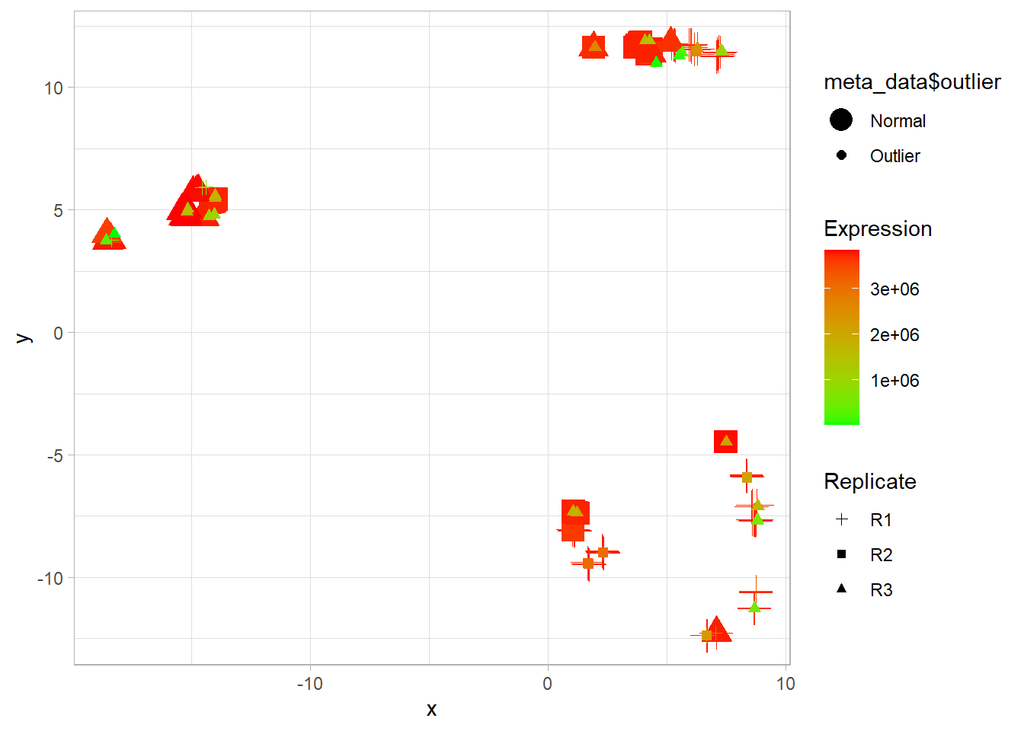

```r
tsne_plot_norm <- data.frame(x = tsne_norm$Y[,1], y = tsne_norm$Y[,2])
ggplot(tsne_plot_norm, aes(x, y, shape=meta_data$Replicate, colour = meta_data$total_exp, size=meta_data$outlier))+
  geom_point()+
  scale_color_gradient(name = 'Expression', low = 'green', high = 'red') +
  scale_shape_manual(name = 'Replicate', values = c(3, 15, 17))+
  scale_size_manual(values = c("Normal" = 5, "Outlier" = 2))+
  theme_light()
```

### PCA

#### With outliers

Moreover, on the y-axis from PC2, there is also a clear segregation between two clusters, top-left and bottom-left. If we were to take a look at the plot with divided by variables, we would know that this two clusters are separated by specimen part, as the samples from the head are located all on the bottom and the bodies without head are on top.

Hence, the specimen part is the second biggest variation factor. This conclusion is not surprising as in the outliers’ barplot, it was clear that most of the outliers came from the samples done with the head.

##### Overall image

```r
pca_plot <- ggplot(df_norm, aes(x=PC1, y=PC2, shape=rep, colour =exp))+
  geom_point()+
  scale_color_gradient(name = 'Expression', low = 'green', high = 'red') +
  scale_shape_manual(name = 'Replicate', values = c(3, 15, 17))+
  theme_light()+
  ggtitle("PCA representation with outliers")
ggplotly(pca_plot)
```

[interactive chart not shown]

##### Divided by variables

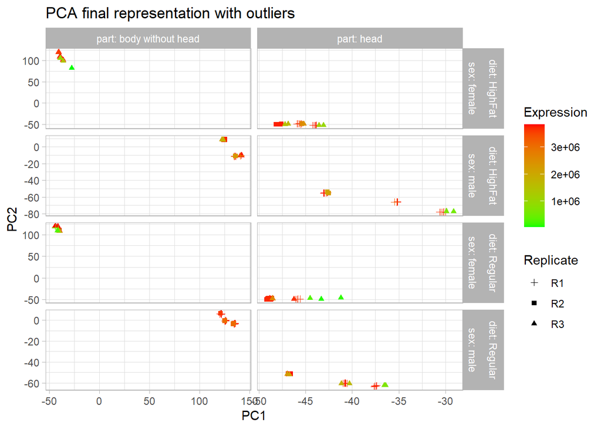

```r
pca_plot +
  facet_grid(diet + sex ~ part, labeller = label_both, scales = "free") +
  theme_light()+
  ggtitle("PCA final representation with outliers")
```

#### Without outliers

```r
meta_data_clean <- meta_data %>% filter(outlier == "Normal")
exprs_norm_clean <- exprs_data_norm[meta_data$outlier == "Normal", ]
gene_variances <- apply(exprs_norm_clean, 2, var)
exprs_norm_filtered <- exprs_norm_clean[, gene_variances > 0]
pca_result_clean <- prcomp(exprs_norm_filtered, scale. = TRUE)
data_plot_pca_clean <- cbind(pca_result_clean$x, meta_data_clean)
```

After removing the outliers, the plot did not substantially change the global PCA structure, as the same clusters’ positions are maintained, implying the same conclusions as before (main variance due to sex, and secondly due to specimen part). This could indicate that the major sources of variation in the dataset are caused primarily by biological factors rather than by the outlier samples (mainly replicate 3).

However, if we were to look in the variability explained in this plot, the cleaned version slightly explained a larger proportion of the total variance, suggesting a reduction in background variability (noise) and a clearer separation of the biological factors.

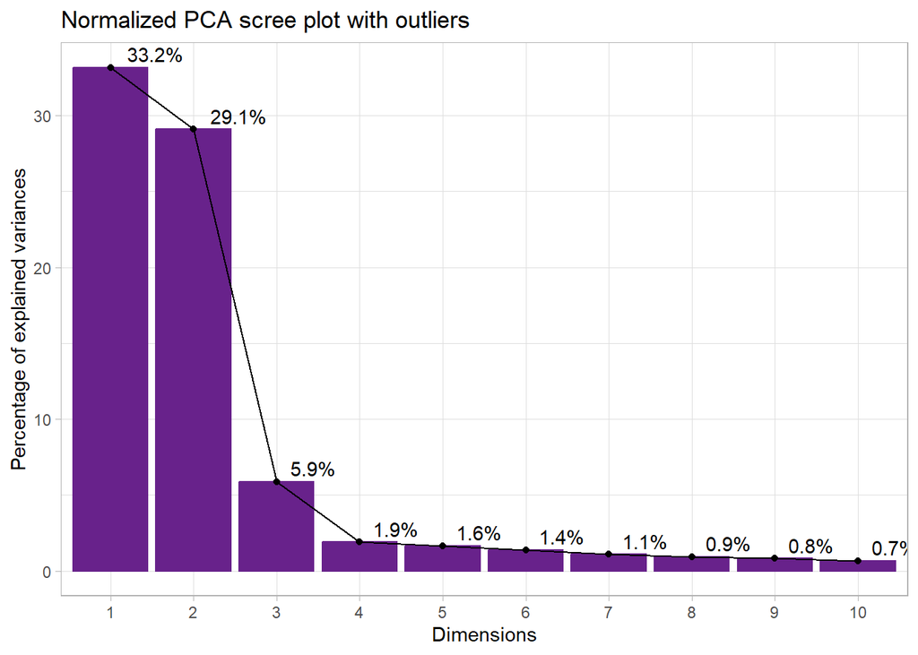

```r
plot_pca_scree_function(pca_result, "#68228B")+
  labs(title="Normalized PCA scree plot with outliers")
```

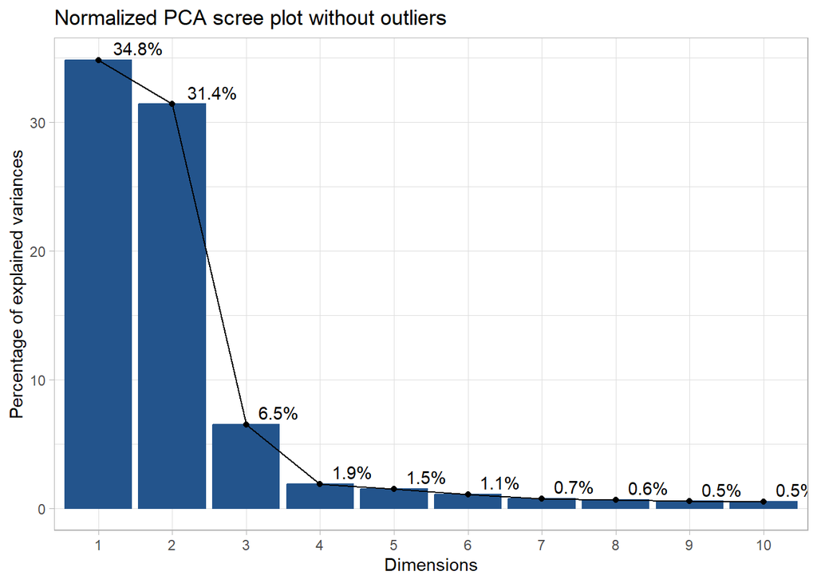

```r
plot_pca_scree_function(pca_result_clean, "#23548C")+
  labs(title="Normalized PCA scree plot without outliers")
```

##### Overall image

```r
pca_plot_final <- ggplot(data_plot_pca_clean, aes(x=PC1, y=PC2, shape=Replicate, colour=total_exp)) +
  geom_point(size = 2.5) +
  scale_color_gradient(name = 'Expression', low = 'green', high = 'red') +
  scale_shape_manual(name = 'Replicate', values = c(3, 15, 17)) +
  theme_light() +
  ggtitle("True PCA on normalized data (No outliers)")

ggplotly(pca_plot_final)
```

[interactive chart not shown]

##### Divided by variables

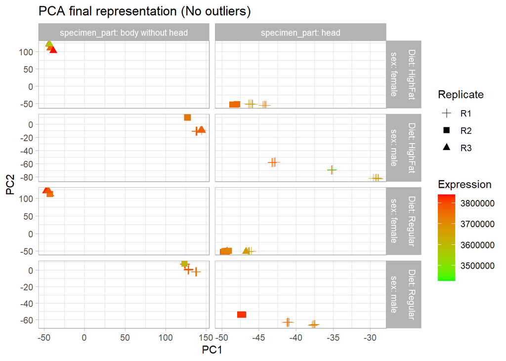

```r
pca_plot_final +
  facet_grid(Diet + sex ~ specimen_part, labeller = label_both, scales = "free") +
  theme_light()+
  ggtitle("PCA final representation (No outliers)")
```

### tSNE

#### With outliers

By preserving the outliers, we can observe that the clusters are mainly formed by the different sex. The top corner and left-middle clusters are formed almost exclusively by females, while the bottom-right one there are only males.

It occurs the same with specimen part. The clusters from top and bottom-right are formed mostly by head samples, and the other one from body samples. As we said before, it is not shocking as we have discovered that most of the head samples from R3 tend to have a low-expression value, hence, the tSNE algorithm considered them from the same group.

##### Overall image

```r
tsne_plot <- ggplot(df_norma, aes(x=tSNE1, y=tSNE2, shape=rep, colour =exp))+
  geom_point()+
  scale_color_gradient(name = 'Expression', low = 'green', high = 'red') +
  scale_shape_manual(name = 'Replicate', values = c(3, 15, 17))+
  theme_light()+
  ggtitle("tSNE representation with outliers")
ggplotly(tsne_plot)
```

[interactive chart not shown]

##### Divided by variables

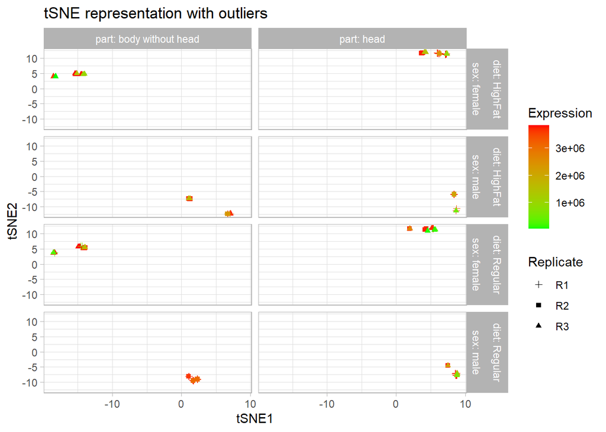

```r
tsne_plot +
  facet_grid(diet + sex ~ part, labeller = label_both, scales = "fixed") +
  theme_light()+
  ggtitle("tSNE representation with outliers")
```

#### Without outliers

Similarly, there also are two out of two clusters formed mainly by specimens taken from the head, and the others from the bodies without head.

Though we cannot use the axis of the tSNE for comparison, we can state that larger the distance between clusters, more different the samples. Hence, it is clearly observable that the clusters classified by gender are at the two extremes of the plot, and the ones from specimen part are relatively also far way from each other.

##### Overall image

```r
set.seed(42)
tsne_norm_clean <- Rtsne(exprs_norm_filtered)

df_tsne_c <- data.frame(x = tsne_norm_clean$Y[,1], y = tsne_norm_clean$Y[,2])
data_plot_tsne_clean <- cbind(df_tsne_c, meta_data_clean)

tsne_plot_final <- ggplot(data_plot_tsne_clean, aes(x, y, shape=Replicate, colour=total_exp)) +
  geom_point() +
  scale_color_gradient(name = 'Expression', low = 'green', high = 'red') +
  scale_shape_manual(name = 'Replicate', values = c(3, 15, 17)) +
  theme_light() +
  ggtitle("True tSNE on normalized data (No outliers)")+
  xlab("tSNE1")+
  ylab("tSNE2")

ggplotly(tsne_plot_final)
```

[interactive chart not shown]

##### Divided by variabless

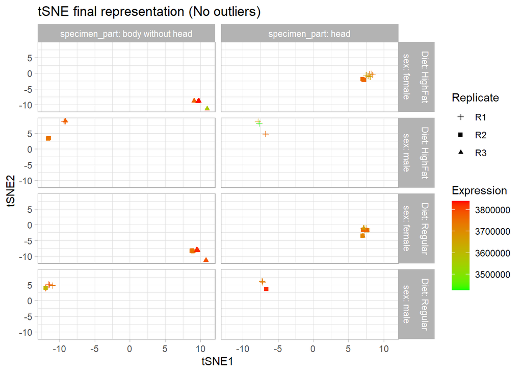

```r
tsne_plot_final +
  facet_grid(Diet + sex ~ specimen_part, labeller = label_both, scales = "fixed") +
  theme_light()+
  ggtitle("tSNE final representation (No outliers)")
```

### Comparison PCA & tSNE

#### Results

To sum up, it can be stated that both algorithms reached the same conclusion; the main factor of variance was caused by sex, implying that there is a huge biological dependence between gene expression and gender. Furthermore, the second source of variation comes from the part of the fly where the sample was extracted

Another important comment is regarding the outliers found. Even though we could spot some samples with low-expression, and consider it as an outlier, the removal of these did not affect PCA and tSNE. This could be because (mentioned before) they are not the main source of variation, such were not differentiated enough in order to have them as a group. Reinforcing then that gender and specimen part difference is massive in comparison to possible outliers.

```r
meta_data <- meta_data_clean #change it so as to use the previous functions
```

##### Diet

```r
p_tsne_diet <- plot_tsne_function(tsne_norm_clean, "Diet")
p_pca_diet <- plot_pca_ggplot(pca_result_clean, "Diet")
div(
  style = "display: flex; justify-content: center; gap: 20px; width: 100%;",
  p_pca_diet,
  p_tsne_diet
)
```

[interactive chart not shown]

##### Specimen part

```r
p_tsne_part <- plot_tsne_function(tsne_norm_clean, "specimen_part")
p_pca_part <- plot_pca_ggplot(pca_result_clean, "specimen_part")
div(
  style = "display: flex; justify-content: center; gap: 20px; width: 100%;",
  p_pca_part,
  p_tsne_part
)
```

[interactive chart not shown]

##### Sex

```r
p_tsne_sex <- plot_tsne_function(tsne_norm_clean, "sex")
p_pca_sex <- plot_pca_ggplot(pca_result_clean, "sex")
div(
  style = "display: flex; justify-content: center; gap: 20px; width: 100%;",
  p_pca_sex,
  p_tsne_sex
)
```

[interactive chart not shown]